# DCG user manual

McCowan Lab & Fushing Lab

December 28, 2015

#### Introduction

The R code for data cloud geometry is designed to find multi-level structure in undirected network data (e.g. edgelist or matrix)[Chen and Fushing 2012]. This multi-level structure is equivalent to finding community structure, similar to the Girvan-Newman method of finding network modularity [Newman and Girvan 2004]. This method begins with a similarity matrix, where the entries of the matrix are a measure of how similar a pair of individuals is with respect to a particular feature. Similarity can be measured based on grooming relationships (where the strength of grooming per dyad is the measure of similarity) or other affiliative relationships. Similarity can also be measured using physical traits or genetic code. The data cloud geometry method involves performing a random walk across all nodes in the network. The probability of making a step from one node to another is based upon their strength of similarity (i.e. from the value in the similarity matrix). Such random walks proceed locally, going to and from a local subset of nodes. Once a subset of nodes has been visited sufficiently (e.g. when one node from that community has been visited at least 5 times, M = 5) that node is removed from the network such that it may no longer be visited. Once all nodes from a community have been removed in this manner, the random walk is forced to jump to another community. This is how communities are defined – the subset of nodes that is each visited 5 times before jumping to a new set of nodes is one community.

#### Installing the package

To install “DCG” package in R, you need to put the package file in your working directory and run `install.packages("./")`.

#### Importing data

DCG package works on similarity matrices. It required the raw data to be an edgelist or a matrice. DCG is designed for undirected networks, i.e. where the direction of the interaction doesn’t matter. The function `as.simMat` is used to convert the raw data to a similarity matrix whose values range from 0 to 1 by dividing this by the maximum value of the matrix. You could assess help files by running `?as.simMat`.

```r
library(DCG)
head(myData)
```

```
##   Initiator Recipient
## 1     35281     35510
## 2     35281     35510
## 3     35281     36003
## 4     35281     36003
## 5     35281     36003
## 6     35281     36182
```

```r
Sim <- as.simMat(myData)  # as.simMat checked. # documented
```

#### Selecting temperatures

Because the random walk proceeds based upon similarity, the range of variance in similarity will influence how close two nodes appear to be. Therefore, the similarity matrix must be evaluated at several different ‘temperatures’. For example, the similarity matrix Sim can be transformed to Sim^0.5, Sim^2, Sim^5, and Sim^10; the scale of variance within each matrix will allow the random walk to assess similarity at different levels.

The function `temperatureSample` is used to generate temperatures. The `start` and `end` arguments defined the lowest and highest temperatuers respectively. The argument `n` defined the number of temperatures you want to sample, with default being 20. The `method` argument allow you to sample temperatures randomly (`"random"`) or based on fixed intervals (`"fixedInterval"`).

```r
set.seed(1)

temperatures <- temperatureSample(start = 0.01, end = 20, n = 20, method = 'random') # documented
```

#### Getting ensemble matrices

The function `getEnsList` is used to get the similarity matrix Sim of different scaled variances, called an internal function `EstClust` on each of the matrix to run `MaxIt` consecutive regulated random walks (1000 by default) with the node removal parameter m (5 by default), and returned a list of ensemble matrices which is used later on in determining clusters. We used `MaxIt = 5` for illustration because it ran quickly.

```r
Ens_list <- getEnsList(Sim, temperatures, MaxIt = 5, m = 5)
```

This process so far is illustrated in figure 1.

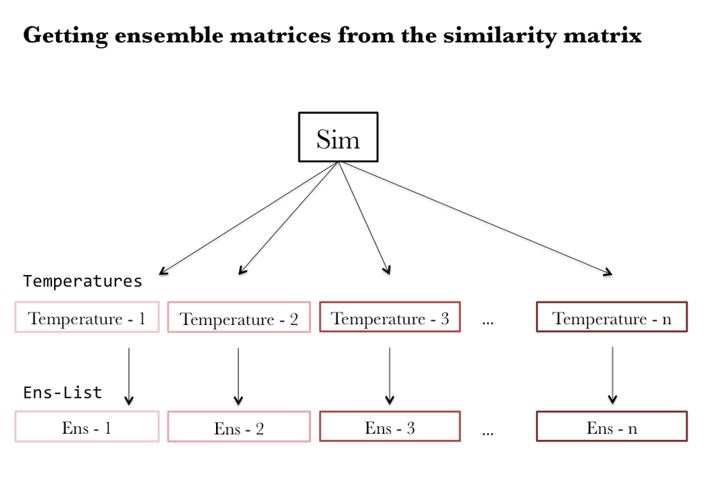

#### Determining number of clusters

The appropriate number of clusters is determined by examining the eigenvalue plot. The function `getEigenvalueList` is used to get eigenvalues for each of the ensemble matrix in the ensemble matrix list (`Ens_list`).

```r
eigenvalue_list <- getEigenvalueList(Ens_list)
```

The function `plotMultiEigenvalues` is used to plot each eigenvalues

```r
plotMultiEigenvalues(eigenvalue_list, "eigenvaluePlots")
```

```
## eigen value plots can be found at './eigenvaluePlots.pdf'
```

```r
plotForest(Ens_list, "myfirtforest")
```

```
## tree plots can be found at './myfirtforest.pdf'
```